# Preparing data

Bennour MH

This is part of the competition of held by the AI_hack in tunisia 2019, the data is form the Tunisian ministry of finance, and the objective is to detect fraudulent tax returns, depending on the variables presented in the data.

This work has not been uploaded nor submitted, this just a mere sharing of what I am learning and trying to do. [here’s the link for the competition in zindi](https://zindi.africa/competitions/ai-hack-tunisia-6-predictive-analytics-challenge-3)

PS: this notebook only include preprocessing, visualization, and cleaning steps, predicting is going to be done in a another python notebook. I hope that you find this helpfull, your feedback would be appreciated.

Let’s load our toolbox

```r
#import data

train <- read_csv("~/Rprojects/tax_fraud/train.csv")
test <- read_csv("~/Rprojects/tax_fraud/test.csv")
```

## Exploring the data

**missing values**

Let’s take a look on how much MV we have. We will explore, and treat them as we proceed in the analysis.

```r
# is there any missing values in the data set.?

train %>%
  is.na %>%
  sum
```

```
## [1] 807069
```

**target variable**

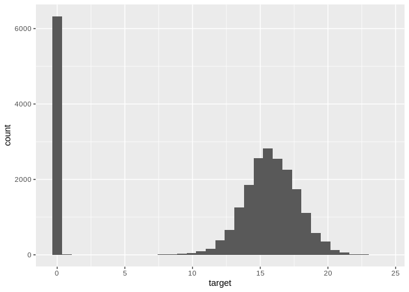

```r
# let's see what is the target variable and how it is distributed
# 0 is for the non fraudulent object, else have to adjust their tax returns

train %>%
  ggplot(aes(x = target)) +
  geom_histogram(bins = 35)
```

```r
train %>%
  pull(target) %>%
  as.factor() %>%
  table %>% as_tibble()
```

```
## # A tibble: 18,370 x 2
##    .                     n
##    <chr>             <int>
##  1 0                  6325
##  2 0.693147180559945    18
##  3 5.14749447681345      1
##  4 6.14846829591765      1
##  5 6.42486902390539      1
##  6 6.68586094706836      1
##  7 6.71295620067707      1
##  8 7.10002716662926      1
##  9 7.21376830811864      1
## 10 7.35436233042148      1
## # … with 18,360 more rows
```

- we need to note that:
- there are mainly 2 categories in the data
  - 0 & approximation to 0 : as seen in the last table, we have some values that are close to zero, I’d like to consider the objects of these values non fraudulent too.
  - Non 0: we can see that in the plot above, we have the non fraudulent distribution on the left, as one high bar in 0, and 18 more values in the approximation (<1), and the rest are normally shaped.

what is needed to be done, is to study more the distribution of the fraudulent and non fraudulent subjects, in accordance with other variables pricesly: CTR_CATEGO_X

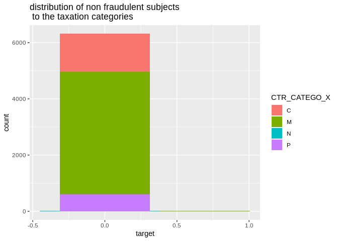

```r
train %>%
  select(target, CTR_CATEGO_X) %>%
  filter(target < 5) %>%
  ggplot(aes(x = target, fill = CTR_CATEGO_X)) +
  geom_histogram(stat = "count") +
  labs(title = "distribution of non fraudulent subjects\n to the taxation categories")
```

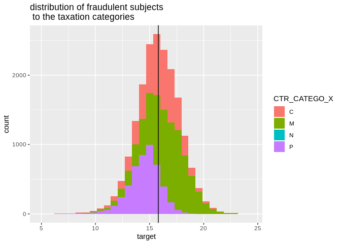

```r
train %>%
  select(target, CTR_CATEGO_X) %>%
  filter(target > 4) %>%
  ggplot(aes(x = target, fill = CTR_CATEGO_X)) +
  geom_histogram() +
  geom_vline(aes(xintercept = mean(target))) +
  labs(title = "distribution of fraudulent subjects\n to the taxation categories")
```

Deeper look into MVs:

```r
# look for NAs  in each variable

train %>%
  sapply(., is.na) %>%
  as_tibble() %>%
  sapply(., sum) %>%
  table() %>% as_tibble()
```

```
## # A tibble: 10 x 2
##    .         n
##    <chr> <int>
##  1 0        19
##  2 10        9
##  3 1974     58
##  4 6043      5
##  5 18742     1
##  6 20681     7
##  7 21631     7
##  8 22579     4
##  9 22940     4
## 10 23610     7
```

We just are trying to figure, why do we have these MVs, and how do they behave, the imputation is going to be the last step.

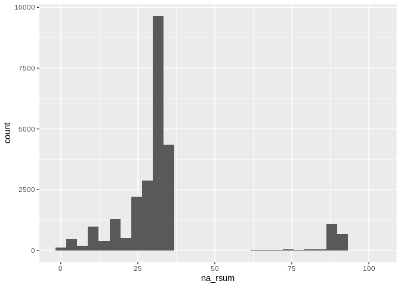

```r
# how are these MVs are distributed across the rows in the data.?

train %>%
  mutate(na_rsum = rowSums(is.na(.))) %>%
  select(na_rsum) %>%
  ggplot(aes(x = na_rsum)) +
  geom_histogram()
```

```r
train %>%
  mutate(na_rsum = rowSums(is.na(.))) %>%
  filter(na_rsum == 0)
```

```
## # A tibble: 35 x 122
##    BCT_CODBUR CTR_MATFIS CTR_CATEGO_X FJU_CODFJU CTR_CESSAT ACT_CODACT
##         <dbl>      <dbl> <chr>             <dbl>      <dbl>      <dbl>
##  1         37       9971 M                    21          0       5804
##  2        500      10059 M                    21          0       4753
##  3        500      11785 M                    21          0       5702
##  4        196       8346 M                    22          0       5703
##  5        700      14137 M                    21          0       2702
##  6        500      11684 M                    21          0       5203
##  7        291      12111 M                    22          0       5606
##  8        500       2189 M                    21          0       5703
##  9        700       3949 M                    22          0       2702
## 10        197       2131 M                    21          0       5506
## # … with 25 more rows, and 116 more variables: CTR_OBLDIR <dbl>,
## #   CTR_OBLACP <dbl>, CTR_OBLRES <dbl>, CTR_OBLFOP <dbl>,
## #   CTR_OBLTFP <dbl>, CTR_OBLDCO <dbl>, CTR_OBLTVA <dbl>,
## #   CTR_OFODEC <dbl>, CTR_OFODEP <dbl>, CTR_OFODET <dbl>,
## #   CTR_OBLAUT <dbl>, CTR_OBLASS <dbl>, CTR_ODTIMB <dbl>,
## #   CTR_OBLTCL <dbl>, CTR_OBLTHO <dbl>, CTR_OBLDLI <dbl>,
## #   CTR_OBLTVI <dbl>, CTR_RATISS <dbl>, EXE_EXERCI <dbl>,
## #   TVA_CHAFF6 <dbl>, TVA_CHAFF7 <dbl>, TVA_CHAF10 <dbl>,
## #   TVA_CHAF12 <dbl>, TVA_CAF125 <dbl>, TVA_CHAF15 <dbl>,
## #   TVA_CHAF18 <dbl>, TVA_CHAF22 <dbl>, TVA_CHAF29 <dbl>,
## #   TVA_CHAF36 <dbl>, TVA_TOTDUE <dbl>, TVA_MOIDEB <dbl>,
## #   TVA_CRDINI <dbl>, TVA_BASIMB <dbl>, TVA_DEDIMB <dbl>,
## #   TVA_BASEQL <dbl>, TVA_DEDEQL <dbl>, TVA_BASEQI <dbl>,
## #   TVA_DEDEQI <dbl>, TVA_BASAUL <dbl>, TVA_DEDAUL <dbl>,
## #   TVA_BASAUI <dbl>, TVA_DEDAUI <dbl>, TVA_BASRSM <dbl>,
## #   TVA_DEDRSM <dbl>, TVA_RSNRES <dbl>, TVA_TRSPOR <dbl>,
## #   TVA_DEDREG <dbl>, TVA_RESTIT <dbl>, TVA_MNTPAY <dbl>,
## #   TVA_MOIFIN <dbl>, TVA_CRDFIN <dbl>, TVA_ACHSUS <dbl>,
## #   TVA_ACHEXO <dbl>, TVA_ACHNDD <dbl>, TVA_CAFEXP <dbl>,
## #   TVA_CAFSUS <dbl>, TVA_CAFEXO <dbl>, TVA_AACHAB <dbl>,
## #   TVA_CRDBLQ <dbl>, TVA_CRDRES <dbl>, TVA_CRDRMP <dbl>,
## #   TVA_CRDREP <dbl>, TVA_CRDRMC <dbl>, TVA_MACHN <dbl>, TVA_MCESQ <dbl>,
## #   TVA_MTVLSM <dbl>, TVA_TXVLSM <dbl>, TVA_MTALSM <dbl>,
## #   TVA_TXALSM <dbl>, TVA_MTORDTVA <dbl>, TVA_MTDJRTVA <dbl>,
## #   TVA_MTORDTAX <dbl>, TVA_MTDJRTAX <dbl>, TVA_MTRESTAX <dbl>,
## #   TVA_CA072018 <dbl>, TVA_CA132018 <dbl>, TVA_CA192018 <dbl>,
## #   ADB_MNTORD <dbl>, SND_MNTPRD_I <dbl>, SND_MNTTVA_I <dbl>,
## #   SND_MNTDRC_I <dbl>, SND_MNTAVA_I <dbl>, SND_MNTTAX_I <dbl>,
## #   SND_MNTPAY_I <dbl>, SND_MNTAIR_I <dbl>, SND_MNTPRD_E <dbl>,
## #   SND_MNTTVA_E <dbl>, SND_MNTDRC_E <dbl>, SND_MNTAVA_E <dbl>,
## #   SND_MNTTAX_E <dbl>, SND_MNTPAY_E <dbl>, SND_MNTAIR_E <dbl>,
## #   SND_MNTPRD_A <dbl>, SND_MNTTVA_A <dbl>, SND_MNTDRC_A <dbl>,
## #   SND_MNTAVA_A <dbl>, SND_MNTTAX_A <dbl>, SND_MNTPAY_A <dbl>,
## #   SND_MNTAIR_A <dbl>, AX1_BRTIMP <dbl>, …
```

we will start by analyzing the structure of the data. I always try to find the different types of data first, in this case, having 100+ variables, it isn’t efficient to use str().

```r
# How much characters as variables do we have.?

train %>%
  select_if(is.character) %>%
  ncol()
```

```
## [1] 2
```

```r
# How much numerical variables do we have.?

train %>%
  select_if(is.numeric) %>%
  ncol()
```

```
## [1] 119
```

Another issue, that I always try to follow it, is the missing values issue, because the ammout of missing values and the strategy we use to impute is crucuial for a generalized model.

```r
# total number of cases

ncol(train) * nrow(train)
```

```
## [1] 3031413
```

```r
ncol(test) * nrow(test)
```

```
## [1] 1288560
```

```r
# How much MVs do we have in training set.?

train %>%
  is.na() %>%
  sum() / 3031413
```

```
## [1] 0.2662353
```

```r
# Do we have the same thing in the test set.?
test %>%
  is.na() %>%
  sum() / 1288560
```

```
## [1] 0.2669468
```

We have almost the same rate of missing values, that is 27% for the train and the test set. this means that we need to pay attention to the imputation strategy later on.

```r
# this helps viewthe structure of the regression later on.

train %>%
  recipe(target ~.) %>%
  summary()
```

```
## # A tibble: 121 x 4
##    variable     type    role      source
##    <chr>        <chr>   <chr>     <chr>
##  1 BCT_CODBUR   numeric predictor original
##  2 CTR_MATFIS   numeric predictor original
##  3 CTR_CATEGO_X nominal predictor original
##  4 FJU_CODFJU   numeric predictor original
##  5 CTR_CESSAT   numeric predictor original
##  6 ACT_CODACT   numeric predictor original
##  7 CTR_OBLDIR   numeric predictor original
##  8 CTR_OBLACP   numeric predictor original
##  9 CTR_OBLRES   numeric predictor original
## 10 CTR_OBLFOP   numeric predictor original
## # … with 111 more rows
```

- Final steps:
  - removing the zero variance variables
  - knn imputing
  - and min_max normalization of the data

```r
# zero variance variables removal

zv <- train %>% nearZeroVar(saveMetrics = T)

zvc <- train[,zv$zeroVar == T] %>% colnames()

train_1 <- train %>% select(-zvc)

# Knn imputation, and min_max normalization

df_1 <- train_1 %>%
  preProcess(., method = c("knnImpute", "range")) %>%
  predict(., train)

# One hot encoding of the CTR_CATEGO_X

df <- df_1 %>%
  select(CTR_CATEGO_X) %>%
  dummyVars(~., data = .) %>%
  predict(., df_1) %>%
  as_tibble() %>%
  bind_cols(df_1) %>%
  select(-CTR_CATEGO_X, -id)
```

Dividing the data for inhouse train and test data for local evaluation.

```r
set.seed(27)
i <- createDataPartition(df$target, times = 1, p = .75, list = F)
train_set <- df[i, ]
test_set <- df[-i, ]

y1 <- train_set$target
y2 <- test_set$target
```

writing out the new test and train sets for local predictions

```r
write_csv(train_set, "~/Rprojects/tax_fraud/ahawa/tmp_train.csv")
write_csv(test_set, "~/Rprojects/tax_fraud/ahawa/tmp_test.csv")
```

## Final thoughts:

I tried to use a tidy approach to the code used in this little analysis, alot of work remain to improve the techniques and the speed in conducting such a notebook. Quality is also an important issue, that needs some improvement. Looking forward for your feedbacks and remarques.